# Pathoscope Initial Analysis

Nate Olson

12/16/2014

### Loading Data

```r
library(knitr)
library(ggplot2)
library(outliers)
source('gather_pathoscope.R')
df <- join(pathoDF, sampleDF)
```

## Top matches

The organisms with the top matches were all *Salmonella enterica subspecies enterica*, and the porportion of reads assigned to the top matches was statistically similiar for all replicates (library, and vials).

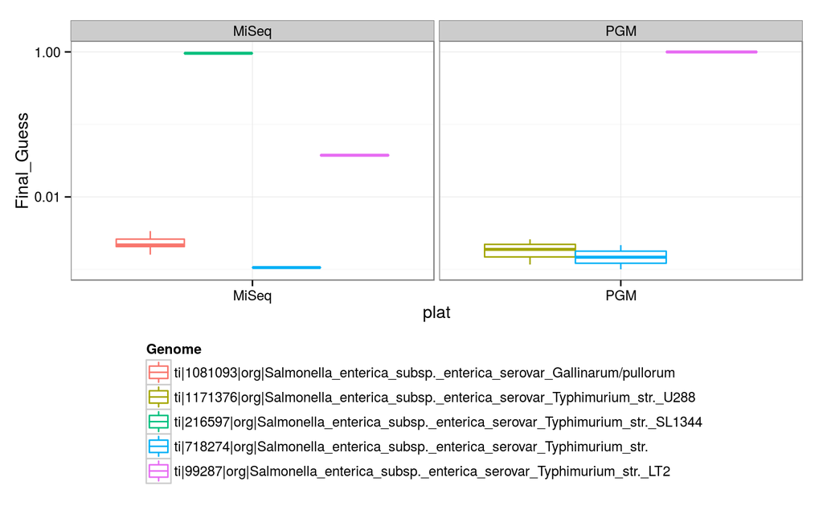

```r
ggplot(df[df$Final_Guess > 0.001,]) + geom_boxplot(aes(y = Final_Guess, x = plat, color = Genome)) + scale_y_log10() +  facet_wrap(~plat, scale = "free_x") + theme_bw() + theme(legend.position = "bottom", legend.direction = "vertical")
```

Top proportion of assignments for all datasets were correct to the subspecies level. LT2 was the top portion for all PGM datasets but not for MiSeq.

### Top Assignment Repeatability

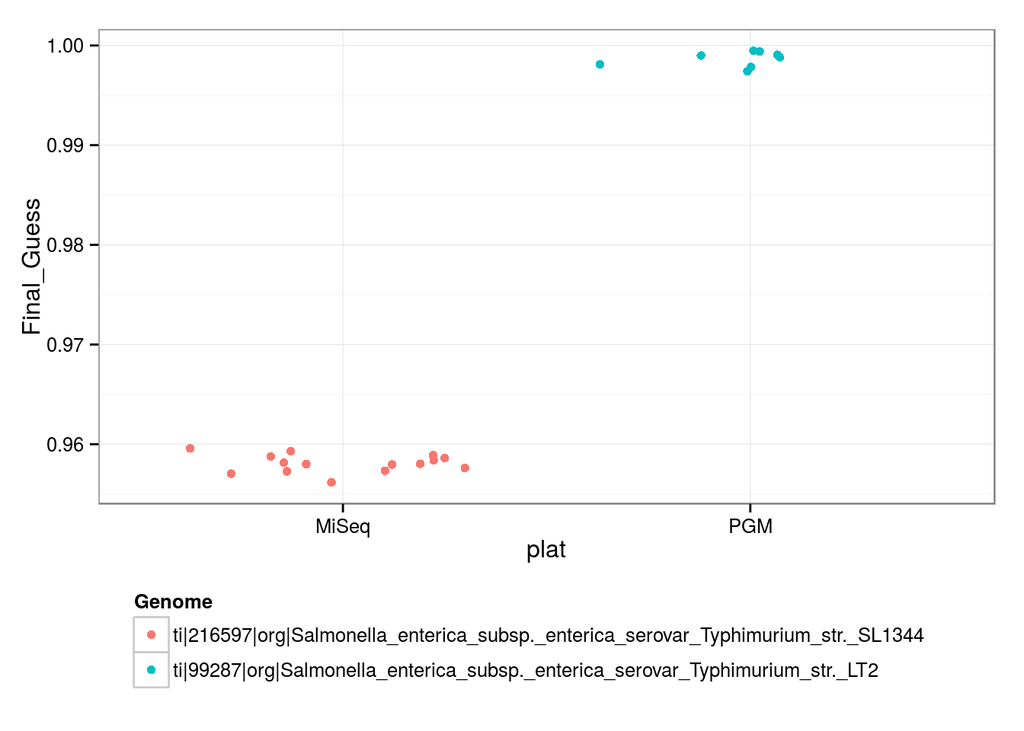

```r
ggplot(df[df$Final_Guess > 0.1,]) + geom_jitter(aes(y = Final_Guess, x = plat, color = Genome))  + theme_bw() + theme(legend.position = "bottom", legend.direction = "vertical")
```

None of the predicted proportion values for the top hit for the sequencing platforms are outliers.

```r
for(i in c("MiSeq","PGM")){
  print(i)
  print(dixon.test(df$Final_Guess[df$Final_Guess > 0.1 & df$plat == i]))
}
```

```
## [1] "MiSeq"
##
##  Dixon test for outliers
##
## data:  df$Final_Guess[df$Final_Guess > 0.1 & df$plat == i]
## Q = 0.3999, p-value = 0.4077
## alternative hypothesis: lowest value 0.956187068637446 is an outlier
##
## [1] "PGM"
##
##  Dixon test for outliers
##
## data:  df$Final_Guess[df$Final_Guess > 0.1 & df$plat == i]
## Q = 0.2187, p-value = 0.9636
## alternative hypothesis: lowest value 0.997400615184494 is an outlier
```

### Proportion of Salmonella

Contaminants defined as any reads not taxonomically classified as Salmonella, the genus level cutoff is based on prior analysis of results pairwwise mixtures of simulated reads from seven different organisms.

```r
df$Contam <- !(grepl("Salmonella", df$Genome))
```

Total proportion of **Salomonella** reads

```r
df_salmonella <- df[df$Contam == FALSE,] %>% ddply(.variables = .(sampleID, plat), summarize, total_prop = sum(Final_Guess))
```

Note that their are only 23 datasets, one missing MiSeq ….

Comparison of Total Salmonella by dataset.

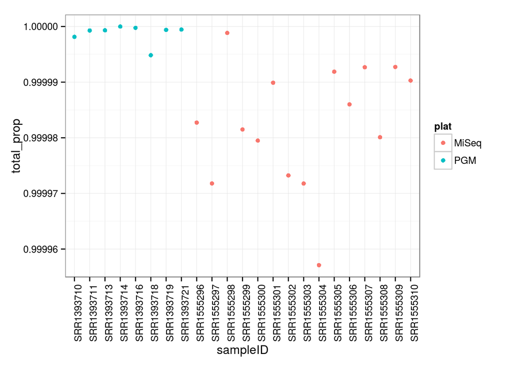

```r
ggplot(df_salmonella) + geom_point(aes(x = sampleID, y = total_prop, color = plat)) + theme_bw() + theme(axis.text.x = element_text(angle = 90))
```

Comparison of total proportions by platform

```r
t.test(x = df_salmonella$total_prop[df_salmonella$plat == "PGM"], y = df_salmonella$total_prop[df_salmonella$plat == "MiSeq"])
```

```
##
##  Welch Two Sample t-test
##
## data:  df_salmonella$total_prop[df_salmonella$plat == "PGM"] and df_salmonella$total_prop[df_salmonella$plat == "MiSeq"]
## t = 5.5948, df = 15.206, p-value = 4.863e-05
## alternative hypothesis: true difference in means is not equal to 0
## 95 percent confidence interval:
##  9.976569e-06 2.223303e-05
## sample estimates:
## mean of x mean of y
## 0.9999988 0.9999827
```

### Analysis of contaminants

Defining contaminants as non-*Salmonella*, sequence purity and genomic sturcture analysis are better suited for evaluating the presence of closely related species within the material.

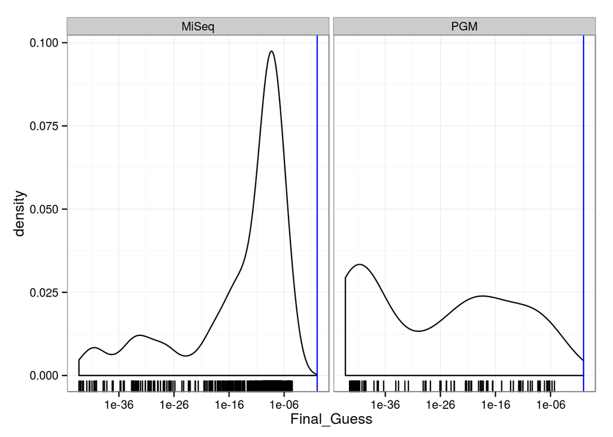

```r
ggplot(df[df$Contam == TRUE,]) + geom_density(aes(x = Final_Guess), alpha = 0.25) + geom_rug(aes(x = Final_Guess)) + facet_wrap(~plat) + geom_vline(aes(xintercept = 1), color = "blue") + scale_x_log10() + theme_bw()
```

Blue vertical line, at 1 to serve as a reference point.

### Contaminant Summary

```r
df_contam <- ddply(df[df$Contam == TRUE,],.variables = .(Genome, plat),summarize, median=median(Final_Guess), max=max(Final_Guess),min=min(Final_Guess)) %>% arrange(desc(median))
```

| Genome | plat | median | max | min |
| --- | --- | --- | --- | --- |
| ti\|32630\|org\|synthetic_construct | MiSeq | 1.11614e-05 | 3.03505e-05 | 0.0000e+00 |
| ti\|696406\|org\|Escherichia_coli_UMNK88 | MiSeq | 5.86550e-06 | 5.86550e-06 | 5.8655e-06 |
| ti\|481805\|org\|Escherichia_coli_ATCC_8739 | MiSeq | 3.83970e-06 | 7.85370e-06 | 9.0400e-08 |
| ti\|300268\|org\|Shigella_boydii_Sb227 | MiSeq | 2.50030e-06 | 2.50030e-06 | 2.5003e-06 |
| ti\|585055\|org\|Escherichia_coli_55989 | PGM | 9.28000e-07 | 1.85610e-06 | 0.0000e+00 |
| ti\|536056\|org\|Escherichia_coli_DH1 | PGM | 6.59700e-07 | 5.14650e-06 | 0.0000e+00 |
| ti\|1246486\|org\|synthetic_Enterobacteria_phage_phiX174.1f | MiSeq | 5.83700e-07 | 1.16730e-06 | 0.0000e+00 |
| ti\|266264\|org\|Cupriavidus_metallidurans_CH34 | MiSeq | 3.15600e-07 | 3.15600e-07 | 3.1560e-07 |
| ti\|910348\|org\|Escherichia_coli_P12b | MiSeq | 2.85800e-07 | 1.17958e-05 | 4.9000e-09 |
| ti\|331112\|org\|Escherichia_coli_HS | PGM | 2.81400e-07 | 3.28100e-07 | 2.3480e-07 |
| ti\|1028764\|org\|Cloning_vector_HPdO | MiSeq | 2.67000e-07 | 5.34000e-07 | 0.0000e+00 |
| ti\|1218933\|org\|Pectobacterium_carotovorum_subsp.*carotovorum*PCC21 | MiSeq | 1.43400e-07 | 2.86700e-07 | 0.0000e+00 |
| ti\|10847\|org\|Enterobacteria_phage_phiX174 | MiSeq | 1.37300e-07 | 4.28380e-06 | 0.0000e+00 |
| ti\|274589\|org\|VCSM13_interference-resistant_helper_phage | MiSeq | 1.23700e-07 | 5.34000e-07 | 0.0000e+00 |
| ti\|0\|org\|Unknown. | MiSeq | 1.18000e-07 | 5.64700e-07 | 4.6000e-09 |
| ti\|693216\|org\|Cronobacter_turicensis_z3032 | MiSeq | 9.92000e-08 | 9.92000e-08 | 9.9200e-08 |
| ti\|585054\|org\|Escherichia_fergusonii_ATCC_35469 | MiSeq | 6.20000e-08 | 1.24100e-07 | 0.0000e+00 |
| ti\|926017\|org\|VCSM13_AviTag-pVII_modified_interference-resistant_helper_phage | MiSeq | 6.18000e-08 | 1.23700e-07 | 0.0000e+00 |
| ti\|926018\|org\|VCSM13_FLAG-pVII_modified_interference-resistant_helper_phage | MiSeq | 6.18000e-08 | 1.23700e-07 | 0.0000e+00 |
| ti\|926019\|org\|VCSM13_HIS6-pVII_modified_interference-resistant_helper_phage | MiSeq | 6.18000e-08 | 1.23700e-07 | 0.0000e+00 |
| ti\|1045856\|org\|Enterobacter_cloacae_EcWSU1 | MiSeq | 5.27000e-08 | 1.09300e-07 | 3.5000e-09 |
| ti\|507522\|org\|Klebsiella_pneumoniae_342 | MiSeq | 5.01000e-08 | 5.02000e-08 | 5.0000e-08 |
| ti\|511145\|org\|Escherichia_coli_str.*K-12*substr._MG1655 | MiSeq | 4.93000e-08 | 4.93000e-08 | 4.9300e-08 |
| ti\|751903\|org\|Human_artificial_chromosome_vector_21HAC4 | MiSeq | 4.58000e-08 | 4.58000e-08 | 4.5800e-08 |
| ti\|215689\|org\|Erwinia_sp._Ejp617 | MiSeq | 4.35000e-08 | 1.95800e-07 | 0.0000e+00 |
| ti\|2341\|org\|primary_endosymbiont_of_Sitophilus_zeamais | MiSeq | 3.83000e-08 | 3.83000e-08 | 3.8300e-08 |
| ti\|536056\|org\|Escherichia_coli_DH1 | MiSeq | 3.46000e-08 | 7.25270e-06 | 0.0000e+00 |
| ti\|10844\|org\|Enterobacteria_phage_S13 | MiSeq | 3.32000e-08 | 3.32000e-08 | 3.3200e-08 |
| ti\|129861\|org\|Phage_Gifsy-1 | MiSeq | 2.75000e-08 | 3.55000e-08 | 1.9500e-08 |
| ti\|439855\|org\|Escherichia_coli_SMS-3-5 | MiSeq | 2.53000e-08 | 2.53000e-08 | 2.5300e-08 |

[output cut: 61 more lines]

Frequency a specific contaminant was observed in a dataset

[figure not shown]

```r
ggplot(df[df$Contam == TRUE & df$Genome %in% df_contam$Genome[df_contam$median > 1e-10],]) + geom_raster(aes(x = sampleID, y = Genome, Fill=Final_Best_Hit_Read_Numbers)) + facet_wrap(~plat, scale= "free_x")
```

Need to filter out Genomes only present in one dataset and order by number of replicates present

### Summary by org

```r
df_summary <- ddply(df,.variables = .(Genome, plat),summarize, median=median(Final_Guess), max=max(Final_Guess),min=min(Final_Guess)) %>% arrange(desc(median))
```

| Genome | plat | median | max | min |
| --- | --- | --- | --- | --- |
| ti\|99287\|org\|Salmonella_enterica_subsp.*enterica*serovar_Typhimurium_str._LT2 | PGM | 0.9989104 | 0.9994742 | 0.9974006 |
| ti\|216597\|org\|Salmonella_enterica_subsp.*enterica*serovar_Typhimurium_str._SL1344 | MiSeq | 0.9580343 | 0.9595847 | 0.9561871 |
| ti\|99287\|org\|Salmonella_enterica_subsp.*enterica*serovar_Typhimurium_str._LT2 | MiSeq | 0.0375543 | 0.0383811 | 0.0369952 |
| ti\|1081093\|org\|Salmonella_enterica_subsp.*enterica*serovar_Gallinarum/pullorum | MiSeq | 0.0021782 | 0.0033778 | 0.0015996 |
| ti\|718274\|org\|Salmonella_enterica_subsp.*enterica*serovar_Typhimurium_str. | PGM | 0.0009326 | 0.0021647 | 0.0000000 |
| ti\|718274\|org\|Salmonella_enterica_subsp.*enterica*serovar_Typhimurium_str. | MiSeq | 0.0007477 | 0.0010610 | 0.0004312 |
| ti\|439851\|org\|Salmonella_enterica_subsp.*enterica*serovar_Dublin_str.*CT*02021853 | MiSeq | 0.0005894 | 0.0007940 | 0.0003154 |
| ti\|1171376\|org\|Salmonella_enterica_subsp.*enterica*serovar_Typhimurium_str._U288 | PGM | 0.0005691 | 0.0025988 | 0.0000000 |
| ti\|605\|org\|Salmonella_enterica_subsp.*enterica*serovar_Pullorum | MiSeq | 0.0001644 | 0.0002526 | 0.0001093 |
| ti\|990282\|org\|Salmonella_enterica_subsp.*enterica*serovar_Typhimurium_str._UK-1 | MiSeq | 0.0001632 | 0.0002754 | 0.0000292 |
| ti\|1171376\|org\|Salmonella_enterica_subsp.*enterica*serovar_Typhimurium_str._U288 | MiSeq | 0.0001345 | 0.0002515 | 0.0000462 |
| ti\|90371\|org\|Salmonella_enterica_subsp.*enterica*serovar_Typhimurium | MiSeq | 0.0001081 | 0.0001500 | 0.0000338 |
| ti\|568708\|org\|Salmonella_enterica_subsp.*enterica*serovar_Typhimurium_str._D23580 | MiSeq | 0.0000690 | 0.0001659 | 0.0000400 |
| ti\|909946\|org\|Salmonella_enterica_subsp.*enterica*serovar_Typhimurium_str._ST4/74 | MiSeq | 0.0000216 | 0.0000581 | 0.0000006 |
| ti\|454169\|org\|Salmonella_enterica_subsp.*enterica*serovar_Heidelberg_str._SL476 | MiSeq | 0.0000192 | 0.0000554 | 0.0000055 |
| ti\|439843\|org\|Salmonella_enterica_subsp.*enterica*serovar_Schwarzengrund_str. | MiSeq | 0.0000155 | 0.0000279 | 0.0000000 |
| ti\|1016998\|org\|Salmonella_enterica_subsp.*enterica*serovar_Paratyphi_B_str._SPB7 | MiSeq | 0.0000146 | 0.0000243 | 0.0000034 |
| ti\|32630\|org\|synthetic_construct | MiSeq | 0.0000112 | 0.0000304 | 0.0000000 |
| ti\|149539\|org\|Salmonella_enterica_subsp.*enterica*serovar_Enteritidis | MiSeq | 0.0000096 | 0.0000291 | 0.0000007 |
| ti\|696406\|org\|Escherichia_coli_UMNK88 | MiSeq | 0.0000059 | 0.0000059 | 0.0000059 |
| ti\|476213\|org\|Salmonella_enterica_subsp.*enterica*serovar_Paratyphi_C_strain | MiSeq | 0.0000049 | 0.0000086 | 0.0000003 |
| ti\|1267753\|org\|Salmonella_enterica_subsp.*enterica*serovar_Javiana_str. | MiSeq | 0.0000042 | 0.0000095 | 0.0000009 |
| ti\|481805\|org\|Escherichia_coli_ATCC_8739 | MiSeq | 0.0000038 | 0.0000079 | 0.0000001 |
| ti\|300268\|org\|Shigella_boydii_Sb227 | MiSeq | 0.0000025 | 0.0000025 | 0.0000025 |
| ti\|117541\|org\|Salmonella_enterica_subsp.*enterica*serovar_Ohio | MiSeq | 0.0000019 | 0.0000019 | 0.0000019 |
| ti\|554290\|org\|Salmonella_enterica_subsp.*enterica*serovar_Paratyphi_A_str. | MiSeq | 0.0000019 | 0.0000031 | 0.0000007 |
| ti\|1008297\|org\|Salmonella_enterica_subsp.*enterica*serovar_Typhimurium_str._798 | MiSeq | 0.0000017 | 0.0000026 | 0.0000000 |
| ti\|59246\|org\|Salmonella_enterica_VI_1,6,14,25:a:e,n,x | MiSeq | 0.0000016 | 0.0000033 | 0.0000000 |
| ti\|295319\|org\|Salmonella_enterica_subsp.*enterica*serovar_Paratyphi_A_str._ATCC | MiSeq | 0.0000010 | 0.0000088 | 0.0000000 |
| ti\|454166\|org\|Salmonella_enterica_subsp.*enterica*serovar_Agona_str._SL483 | MiSeq | 0.0000010 | 0.0000109 | 0.0000000 |

[output cut: 311 more lines]